# MEML_HW4

**Machine Learning for Mechanical Engineering**  
**Homework 04**  
**Due Tuesday, 04/30/2019, 9:30 AM**

By Prof. Seungchul Lee  
http://iai.postech.ac.kr/  
Industrial AI Lab at POSTECH

- For your handwritten solution, hand in your hardcopy before the class begins.
- For your code, email your .ipynb file to iai.postech@gmail.com. Only .ipynb file will be graded.
- When you send an e-mail, write down [Machine Learning Homework] on the title
- And please write your NAME on your .ipynb files. ex) 이남정_20192319 _HW1.ipynb
- Do not submit a printed version of your code. It will not be graded.
- If you have any questions on the homework problems, please email our TA via iai.postech@gmail.com.

# Problem 1

We examined K-means to compress an image by reducing the number of colors in class. We can apply the same method to compress an image down to binary colors (i.e., black and white, and it is the maximum compression). When I, as an instructor, prepare for the lecture materials, I often write some equations down on a whiteboard and take a picture of it to put it in lecture slides as shown in Figure 1. However, if I use it as it is, it will take up a lot of ink or toner when it is printed by a number of students. Since I do not want to waste unnecessary resources and do want to maintain our only one Earth as sustainable as possible, I will ask you to convert it to a binary image which prints only black parts. You can download [handwirtten.jpg](https://www.dropbox.com/s/3de31yyekwi8vys/k_means_handwritten.jpg?dl=1)

[output not shown]

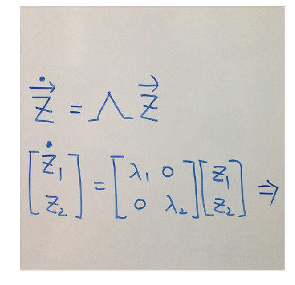

```python
import cv2
import matplotlib.pyplot as plt

img = cv2.imread('./image_files/k_means_handwritten.jpg')
img = cv2.cvtColor(img, cv2.COLOR_BGR2RGB)

plt.figure(figsize=(8,8))
plt.imshow(img)
plt.axis('off')
plt.show()
```

```python
# Your code here
```

# Problem 2

### [Monty Hall Problem](http://en.wikipedia.org/wiki/Monty_Hall_problem) with Monte Carlo Simulations

Suppose you’re on a game show, and you’re given the choice of three doors: Behind one door is a car; behind the others, goats. You pick a door, say No. 1, and the host, who knows what’s behind the doors, opens another door, say No. 3, which has a goat. He then says to you, “Do you want to pick door No. 2?” Is it to your advantage to switch your choice?

```python
%%html
<center><iframe width="560" height="315" src="https://www.youtube.com/embed/HH-676dOCFs?rel=0"
frameborder="0" allowfullscreen></iframe></center>
```

[video not shown]

Solve this problem with monte carlo simulation and print out the winning rate about 'Staying' and 'Switching'

You can utilize the below functions

```python
import numpy as np
from random import shuffle, choice
```

`np.random.randint(x)` : return random integer from 0 to (x-1)

```python
np.random.randint(3)
```

```
2
```

`shuffle(list)` : randomly shuffle the positioin of elements in list

```python
doors = ['car', 'goat', 'goat']
print(doors)
shuffle(doors)
print(doors)
```

```
['car', 'goat', 'goat']
['goat', 'car', 'goat']
```

`choice(list)`: choice random element in list

```python
choice([0, 1, 2])
```

```
1
```

```python
# your code here
```

### Sample output

```
Start simulation ...

Winning rate
Staying: 33.396100%
Switching: 66.603900%
```